# Inside Item Memory

> This notebook focuses on item memory inside the rooms.

# 1 Overview of the data

The rooms were separated into *Familiar* and *Novel* groups. Participants explored the *Familiar* group at the beginning of the experiment. In the encoding task, they visisted both *Familiar* and *Novel* groups. Their item memory (i.e., in which room they saw the item) was tested in the memory test the next day of the encoding task. **Novelty benefits** on the item memory are examined by comparing the memory performance between the *Familiar* and *Novel* groups.

Participants were also asked to rate how curious they felt about the room. The higher the rating is means they felt more curious about the room. Item memory as a function of curiosity rating was also examined for **curiosity benefits**.

Questionnaires on personal traits regarding curiosity were also administered to participants before the encoding task (i.e., PC and EC). Scores on these questionnaires might be able to predict the item memory or its relationship with curiosity rating.

In the encoding task, there were 6 objects in each room, and the participant saw the object after openning each of the six box. It is possbile that the item memory for the object to some extent depends on the order in which the object was seen. For example, it may be easier to remember where the first and last objects were seen as compared to those in the middle.

# 2 Visual inspection of the data

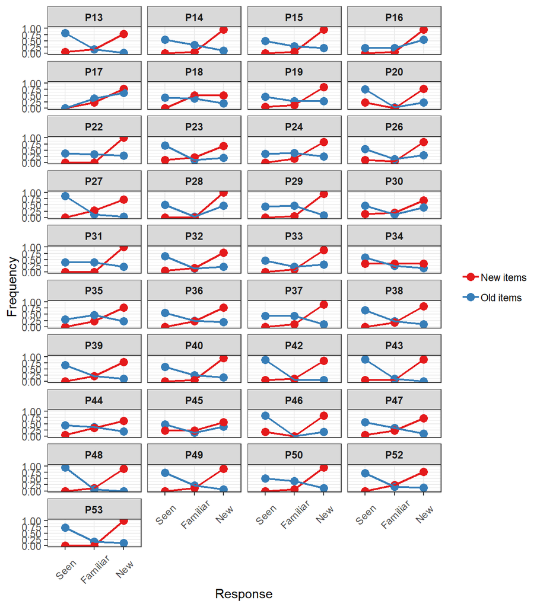

Figure 1. Response frequency for new and old items respectively for each individual participant.

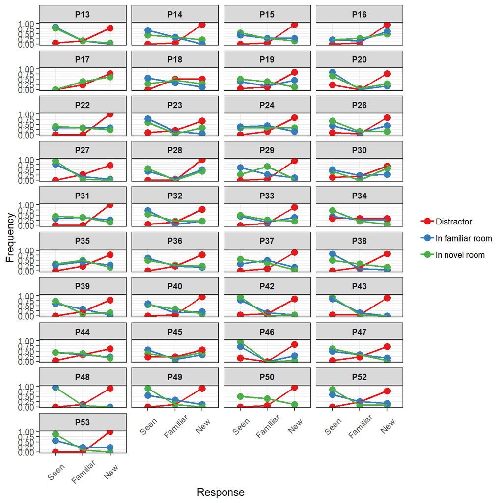

Figure 2. Response frequency for new and old items respectively for each Familiar/Novel group and each individual participant.

# 3 Novelty Benefits

## 3.1 Compare mean accuracy between *novel* and *familiar* rooms

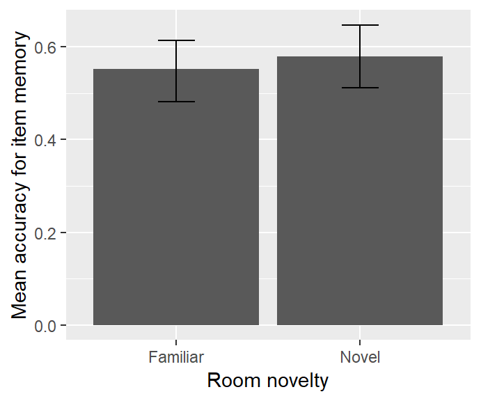

Figure 3. Mean hit rate for recollect response respectively for Familiar and Novel rooms.

```
##
##  Paired t-test
##
## data:  MeanSeenHit by Group
## t = -0.93095, df = 36, p-value = 0.3581
## alternative hypothesis: true difference in means is not equal to 0
## 95 percent confidence interval:
##  -0.08590610  0.03185204
## sample estimates:
## mean of the differences
##             -0.02702703
```

## 3.2 Item memory as a function of item order

### 3.2.1 Visualise the data

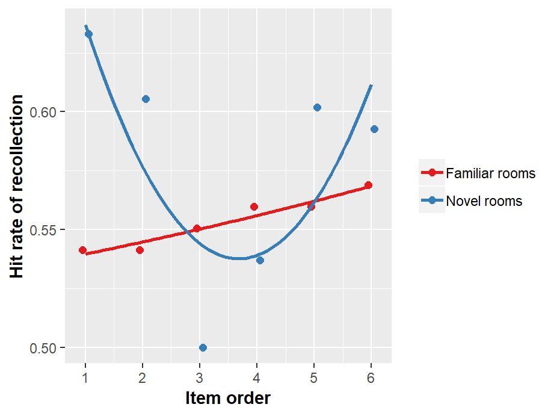

Figure 4. Mean hit rate for seen response for items at each order (i.e., 1st, 2nd, 3rd, etc), respectively for familiar and novel rooms.

### 3.2.2 Testing novelty effects by fitting mixed models

Build models with item memory accuracy as $y$ and iexamine effects of item order and novelty by comparing the models.

- `baseline.item` is the model with only an intercept.
- `order.model.linear.1` is the model with $\small ItemOrder$ included, showing the effects of item order.
- `order.model.linear.2` is the model allowing the slope (i.e., relationship between item memory and item order) varying across participants.
- `order.model.quad.1` and `order.model.quad.2` repectively included $\small ItemOrder^2$ and related random effects.
- `novelty.model.1` is the model with $\small Group$ (i.e., *familiar* and *novel* rooms) included, examining the effects of novelty of the rooms on the intercept (i.e., mean item memory accuracy at the 1st order or overall if no difference in slope).
- `novelty.model.2` is the model with interaction between $\small Group$ and $\small ItemOrder$ included, examining the effects of novelty on how item memory accuracy changes as a function of item order.
- `novelty.model.3` included interaction between $\small Group$ and $\small ItemOrder^2$ for inestigating whether the pattern changes between *familiar* and *novel* groups.

```
##                      Model df      AIC      BIC    logLik   Test  L.Ratio
## order.model.linear.1     1  4 1758.530 1779.222 -875.2648
## order.model.linear.2     2  6 1759.261 1790.300 -873.6305 1 vs 2 3.268691
## order.model.quad.1       3  7 1759.364 1795.576 -872.6820 2 vs 3 1.896904
## order.model.quad.2       4 10 1765.365 1817.097 -872.6824 3 vs 4 0.000771
## novelty.model.1          5 11 1766.428 1823.333 -872.2142 4 vs 5 0.936417
## novelty.model.2          6 12 1767.884 1829.962 -871.9419 5 vs 6 0.544635
## novelty.model.3          7 13 1768.063 1835.314 -871.0314 6 vs 7 1.820943
##                      p-value
## order.model.linear.1
## order.model.linear.2  0.1951
## order.model.quad.1    0.1684
## order.model.quad.2    1.0000
## novelty.model.1       0.3332
## novelty.model.2       0.4605
## novelty.model.3       0.1772
```

Including none of the predictors significantly improved the model fit.

#### 3.2.2.1 Parameter estimation for the complete model

```
## Linear mixed-effects model fit by maximum likelihood
##  Data: Encoding.Recall.Old
##        AIC      BIC    logLik
##   1768.063 1835.314 -871.0314
##
## Random effects:
##  Formula: ~1 + ItemOrder + I(ItemOrder^2) | SubjectNo
##  Structure: General positive-definite, Log-Cholesky parametrization
##                StdDev       Corr
## (Intercept)    0.1969384127 (Intr) ItmOrd
## ItemOrder      0.0312759879 -0.416
## I(ItemOrder^2) 0.0002841597  0.008 -0.051
## Residual       0.4570108544
##
## Fixed effects: SeenHit ~ ItemOrder + I(ItemOrder^2) + Group + ItemOrder:Group +      I(ItemOrder^2):Group
##                                Value  Std.Error   DF   t-value p-value
## (Intercept)                0.5338111 0.08494358 1262  6.284302  0.0000
## ItemOrder                  0.0048336 0.05160649 1262  0.093662  0.9254
## I(ItemOrder^2)             0.0001639 0.00718085 1262  0.022818  0.9818
## GroupNovel                 0.1905332 0.11106560 1262  1.715501  0.0865
## ItemOrder:GroupNovel      -0.1068144 0.07271334 1262 -1.468979  0.1421
## I(ItemOrder^2):GroupNovel  0.0136995 0.01017143 1262  1.346865  0.1783
##  Correlation:
##                           (Intr) ItmOrd I(ItO^2) GrpNvl ItO:GN
## ItemOrder                 -0.872
## I(ItemOrder^2)             0.789 -0.974
## GroupNovel                -0.653  0.655 -0.603
## ItemOrder:GroupNovel       0.608 -0.703  0.691   -0.931
## I(ItemOrder^2):GroupNovel -0.557  0.688 -0.706    0.854 -0.979
##
## Standardized Within-Group Residuals:
##        Min         Q1        Med         Q3        Max
## -1.8984060 -1.0010670  0.3835155  0.8915243  1.6669354
##
## Number of Observations: 1304
## Number of Groups: 37
```

### 3.2.3 Collapse the order

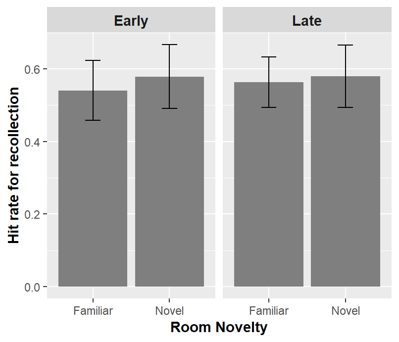

#### 3.2.3.1 Stats on it

```
## Linear mixed-effects model fit by maximum likelihood
##  Data: Encoding.Recall.Old.Collapsed.Grp
##        AIC       BIC  logLik
##   -34.4178 -1.448462 28.2089
##
## Random effects:
##  Formula: ~Group + ItemOrderType | SubjectNo
##  Structure: General positive-definite, Log-Cholesky parametrization
##                   StdDev    Corr
## (Intercept)       0.1902571 (Intr) GrpNvl
## GroupNovel        0.1131267  0.000
## ItemOrderTypeLate 0.1221249 -0.382  0.013
## Residual          0.1322410
##
## Fixed effects: SeenHit ~ Group * ItemOrderType
##                                   Value  Std.Error  DF   t-value p-value
## (Intercept)                   0.5405405 0.03861686 108 13.997527  0.0000
## GroupNovel                    0.0382883 0.03642839 108  1.051056  0.2956
## ItemOrderTypeLate             0.0225225 0.03722673 108  0.605009  0.5464
## GroupNovel:ItemOrderTypeLate -0.0217718 0.04408033 108 -0.493911  0.6224
##  Correlation:
##                              (Intr) GrpNvl ItmOTL
## GroupNovel                   -0.345
## ItemOrderTypeLate            -0.509  0.362
## GroupNovel:ItemOrderTypeLate  0.285 -0.605 -0.592
##
## Standardized Within-Group Residuals:
##         Min          Q1         Med          Q3         Max
## -1.85085720 -0.60339511 -0.03527769  0.56645305  2.12049098
##
## Number of Observations: 148
## Number of Groups: 37
```

# 4 Curiosity Benefits

We hypothesed that the higher the curiosity rating was, the better the item memory should be.

## 4.1 Mean accuracy of item memory as a function of curiosity rating

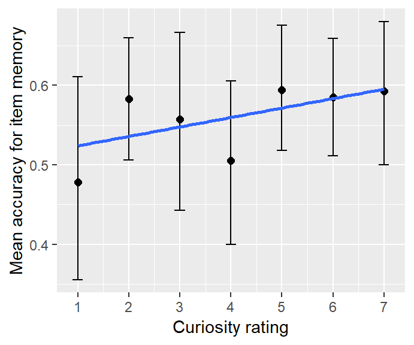

Figure 5. Mean hit rate as a function of curiosity rating.

### 4.1.1 Testing the relationship between mean accuracy of item memory and curiosity rating

Build models with item memory accuracy as $y$ and examine effects of curiosity rating by including it into the model and then comparing the model fits.

- `baseline.rating` is the model with only an intercept, showing no change in item memory as a function of curiosity rating.
- `rating.intercept` is the model with $\small CuriosityRating$ included, showing the effects of curiosity rating.
- `rating.slope` is the model allowing the slope (i.e., relationship between item memory and curiosity rating) varying across participants.

```
##                  Model df       AIC       BIC   logLik   Test  L.Ratio
## baseline.rating      1  3 -15.60218 -5.448691 10.80109
## rating.intercept     2  4 -14.91968 -1.381696 11.45984 1 vs 2 1.317500
## rating.slope         3  6 -12.40790  7.899074 12.20395 2 vs 3 1.488221
##                  p-value
## baseline.rating
## rating.intercept  0.2510
## rating.slope      0.4752
```

Including $\small CuriosityRating$ did not improve the model fit significantly, so may not play an important role.

#### 4.1.1.1 Parameter estimates in the complete model

```r
summary(rating.slope)
```

```
## Linear mixed-effects model fit by maximum likelihood
##  Data: InsideObjectsMemory
##        AIC      BIC   logLik
##   -12.4079 7.899074 12.20395
##
## Random effects:
##  Formula: ~1 + CuriosityRating | SubjectNo
##  Structure: General positive-definite, Log-Cholesky parametrization
##                 StdDev     Corr
## (Intercept)     0.13645001 (Intr)
## CuriosityRating 0.01485669 0.504
## Residual        0.19578301
##
## Fixed effects: SeenHit ~ CuriosityRating
##                     Value  Std.Error  DF   t-value p-value
## (Intercept)     0.5278080 0.04266339 180 12.371451  0.0000
## CuriosityRating 0.0083597 0.00790367 180  1.057701  0.2916
##  Correlation:
##                 (Intr)
## CuriosityRating -0.667
##
## Standardized Within-Group Residuals:
##         Min          Q1         Med          Q3         Max
## -2.45172807 -0.63177579  0.01864646  0.62059274  2.39688057
##
## Number of Observations: 218
## Number of Groups: 37
```

#### 4.1.1.2 Plot the model

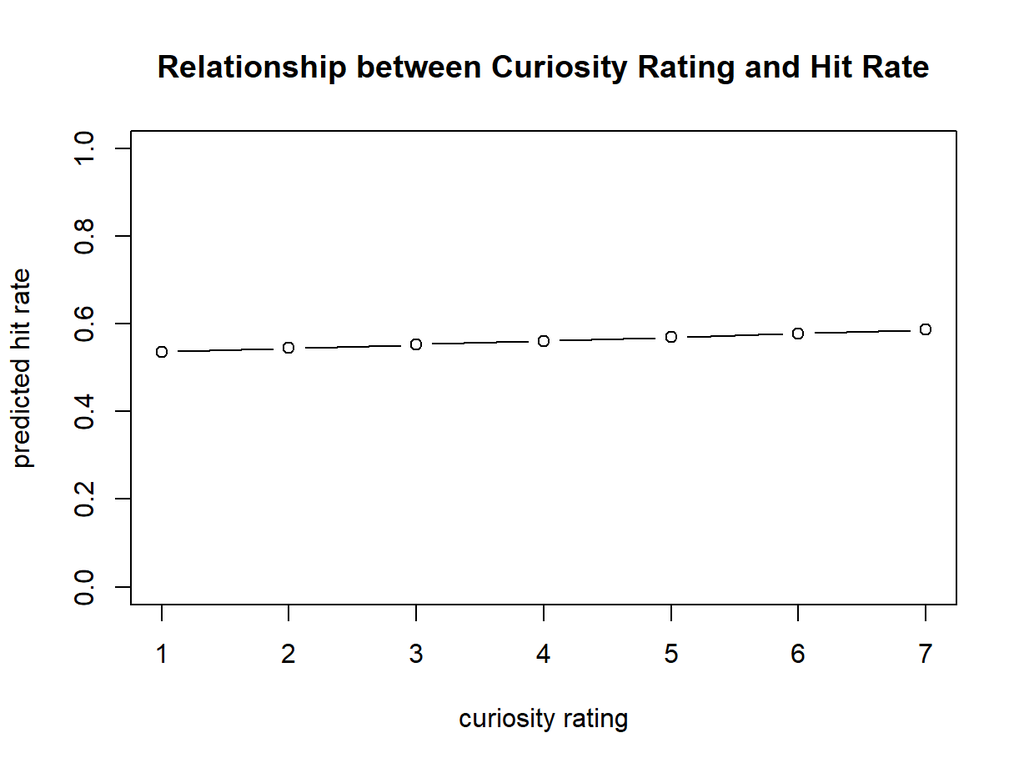

## 4.2 Does the relationship with curiosity rating depend on item order?

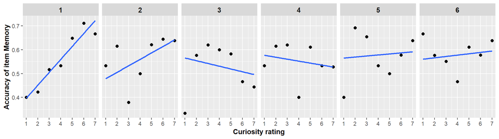

Figure 6. Mean accuracy across participants for item memory as a function of curiosity rating for each order at which the item was seen (I.e., 1st, 2nd, 3rd, etc.).

For four of the six orders, there seems to be a positive correlates between curiosity rating and item memory.

### 4.2.1 Testing the effect of item order

Build models with context memory accuracy as $y$ and examine effects of curiosity rating and item order by comparing the models.

- `item.model.linear.1` is the model with $\small ItemOrder$ included (in addition to $\small CuriosityRating$), showing the effects of item order.
- `item.model.linear.2` is the model allowing the slope (i.e., relationship between item memory and item order) varying across participants.
- `item.model.linear.3` is the model with the interaction between $\small ItemOrders$ and $\small CuriosityRating$ included.
- `item.model.quad.1` and `item.model.quad.2` repectively included $\small ItemOrder^2$ and related random effects.
- `item.model.quad.3` included interaction between $\small ItemOrder^2$ and $\small CuriosityRating$ for inestigating whether the pattern changes as a function of *curiosity rating*.

```r
rating.intercept <- update(baseline.item, .~. + CuriosityRating)
rating.slope     <- update(rating.intercept, random = ~ 1 + CuriosityRating | SubjectNo)

item.model.linear.1     <- update(rating.slope, .~. + ItemOrder)
item.model.linear.2     <- update(item.model.linear.1, random = list(~1+CuriosityRating|SubjectNo, ~1+ItemOrder|SubjectNo))
item.model.linear.3     <- update(item.model.linear.2, .~. + ItemOrder : CuriosityRating)

item.model.quad.1       <- update(item.model.linear.3, .~. + I(ItemOrder^2))
# item.model.quad.2       <- update(item.model.quad.1,   random = list(~1+CuriosityRating|SubjectNo, ~1+ItemOrder+I(ItemOrder^2)|SubjectNo)) - excluding this model because singularity issue (perhaps the model was getting too complex to be calculated)
item.model.quad.3       <- update(item.model.quad.1,   .~. + I(ItemOrder^2) : CuriosityRating)

anova(rating.intercept, rating.slope, item.model.linear.1, item.model.linear.2, item.model.linear.3, item.model.quad.1, item.model.quad.3)
```

```
##                     Model df      AIC      BIC    logLik   Test  L.Ratio
## rating.intercept        1  4 1757.099 1777.791 -874.5493
## rating.slope            2  6 1759.292 1790.331 -873.6461 1 vs 2 1.806478
## item.model.linear.1     3  7 1761.291 1797.503 -873.6455 2 vs 3 0.001100
## item.model.linear.2     4 10 1763.971 1815.703 -871.9856 3 vs 4 3.319790
## item.model.linear.3     5 11 1761.725 1818.630 -869.8627 4 vs 5 4.245793
## item.model.quad.1       6 12 1761.813 1823.892 -868.9067 5 vs 6 1.912097
## item.model.quad.3       7 13 1758.552 1825.803 -866.2759 6 vs 7 5.261452
##                     p-value
## rating.intercept
## rating.slope         0.4053
## item.model.linear.1  0.9735
## item.model.linear.2  0.3449
## item.model.linear.3  0.0393
## item.model.quad.1    0.1667
## item.model.quad.3    0.0218
```

#### 4.2.1.1 Parameter estimation for the complete model

```r
summary(item.model.quad.3)
```

```
## Linear mixed-effects model fit by maximum likelihood
##  Data: Encoding.Recall.Old
##        AIC      BIC    logLik
##   1758.552 1825.803 -866.2759
##
## Random effects:
##  Formula: ~1 + CuriosityRating | SubjectNo
##  Structure: General positive-definite, Log-Cholesky parametrization
##                 StdDev     Corr
## (Intercept)     0.05134803 (Intr)
## CuriosityRating 0.02121837 -0.136
##
##  Formula: ~1 + ItemOrder | SubjectNo %in% SubjectNo
##  Structure: General positive-definite, Log-Cholesky parametrization
##             StdDev     Corr
## (Intercept) 0.16120846 (Intr)
## ItemOrder   0.02902666 -0.417
## Residual    0.45441687
##
## Fixed effects: SeenHit ~ CuriosityRating + ItemOrder + I(ItemOrder^2) + CuriosityRating:ItemOrder +      CuriosityRating:I(ItemOrder^2)
##                                      Value  Std.Error   DF   t-value
## (Intercept)                     0.20193000 0.14788684 1262  1.365436
## CuriosityRating                 0.09514230 0.03006136 1262  3.164937
## ItemOrder                       0.18490848 0.09467370 1262  1.953113
## I(ItemOrder^2)                 -0.02097953 0.01321495 1262 -1.587561
## CuriosityRating:ItemOrder      -0.05188848 0.01942151 1262 -2.671702
## CuriosityRating:I(ItemOrder^2)  0.00621895 0.00271412 1262  2.291336
##                                p-value
## (Intercept)                     0.1724
## CuriosityRating                 0.0016
## ItemOrder                       0.0510
## I(ItemOrder^2)                  0.1126
## CuriosityRating:ItemOrder       0.0076
## CuriosityRating:I(ItemOrder^2)  0.0221
##  Correlation:
##                                (Intr) CrstyR ItmOrd I(IO^2 CrR:IO
## CuriosityRating                -0.903
## ItemOrder                      -0.914  0.850
## I(ItemOrder^2)                  0.834 -0.779 -0.977
## CuriosityRating:ItemOrder       0.843 -0.921 -0.923  0.904
## CuriosityRating:I(ItemOrder^2) -0.771  0.843  0.903 -0.924 -0.978
##
## Standardized Within-Group Residuals:
##        Min         Q1        Med         Q3        Max
## -1.9889397 -1.0095811  0.3723925  0.8819037  1.7116983
##
## Number of Observations: 1304
## Number of Groups:
##                  SubjectNo SubjectNo.1 %in% SubjectNo
##                         37                         37
```

### 4.2.2 Collapse the order and curiosity rating

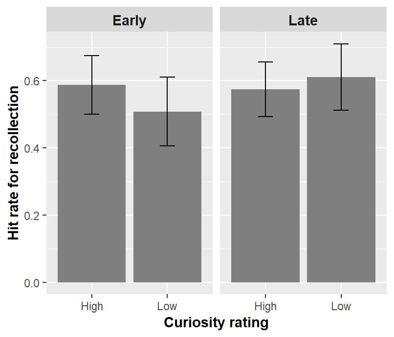

Figure 7. Mean hit rate as a function of item order (Early vs. Late) and curiosity (Low vs. High).

# 5 Curiosity and novelty

## 5.1 Testing the effects of curiosity rating and novelty together

Build models with item memory accuracy as $y$ and examine effects of curiosity rating and novelty together by including them into the model separately and then comparing the model fits.

```
##                   Model df        AIC      BIC   logLik   Test   L.Ratio
## baseline.rating       1  3 -15.602176 -5.44869 10.80109
## rating.intercept      2  4 -14.919676 -1.38170 11.45984 1 vs 2 1.3174997
## rating.slope          3  6 -12.407896  7.89907 12.20395 2 vs 3 1.4882207
## novelty.model.1       4  7 -10.413023 13.27844 12.20651 3 vs 4 0.0051269
## novelty.model.2       5 10  -4.603520 29.24143 12.30176 4 vs 5 0.1904968
## interaction.model     6 11  -4.298425 32.93102 13.14921 5 vs 6 1.6949048
##                   p-value
## baseline.rating
## rating.intercept   0.2510
## rating.slope       0.4752
## novelty.model.1    0.9429
## novelty.model.2    0.9791
## interaction.model  0.1930
```

```
## Linear mixed-effects model fit by maximum likelihood
##  Data: InsideObjectsMemory
##        AIC      BIC   logLik
##   -4.60352 29.24143 12.30176
##
## Random effects:
##  Formula: ~1 + CuriosityRating | SubjectNo
##  Structure: General positive-definite, Log-Cholesky parametrization
##                 StdDev      Corr
## (Intercept)     0.091206340 (Intr)
## CuriosityRating 0.002380474 -0.032
##
##  Formula: ~1 + Group | SubjectNo %in% SubjectNo
##  Structure: General positive-definite, Log-Cholesky parametrization
##             StdDev     Corr
## (Intercept) 0.13383775 (Intr)
## GroupNovel  0.05505111 0.689
## Residual    0.19538395
##
## Fixed effects: SeenHit ~ CuriosityRating + Group
##                     Value  Std.Error  DF   t-value p-value
## (Intercept)     0.5279818 0.05013405 179 10.531402  0.0000
## CuriosityRating 0.0081811 0.01226680 179  0.666928  0.5057
## GroupNovel      0.0015884 0.04438601 179  0.035785  0.9715
##  Correlation:
##                 (Intr) CrstyR
## CuriosityRating -0.756
## GroupNovel       0.487 -0.772
##
## Standardized Within-Group Residuals:
##          Min           Q1          Med           Q3          Max
## -2.468009522 -0.627270929 -0.001542297  0.645100191  2.409046895
##
## Number of Observations: 218
## Number of Groups:
##                  SubjectNo SubjectNo.1 %in% SubjectNo
##                         37                         37
```

## 5.2 What about the other way around

```
##                 Model df       AIC       BIC   logLik   Test   L.Ratio
## baseline.rating     1  3 -15.60218 -5.448691 10.80109
## novelty.model.1     2  4 -14.43297 -0.894988 11.21648 1 vs 2 0.8307917
## novelty.model.2     3  6 -12.23784  8.069129 12.11892 2 vs 3 1.8048740
## rating.model.1      4  7 -10.60588 13.085583 12.30294 3 vs 4 0.3680410
## rating.model.2      5 10  -4.60352 29.241430 12.30176 4 vs 5 0.0023626
##                 p-value
## baseline.rating
## novelty.model.1  0.3620
## novelty.model.2  0.4056
## rating.model.1   0.5441
## rating.model.2   1.0000
```

### 5.2.1 Check the model

```
## Linear mixed-effects model fit by maximum likelihood
##  Data: InsideObjectsMemory
##        AIC      BIC   logLik
##   -4.60352 29.24143 12.30176
##
## Random effects:
##  Formula: ~1 + CuriosityRating | SubjectNo
##  Structure: General positive-definite, Log-Cholesky parametrization
##                 StdDev      Corr
## (Intercept)     0.091206339 (Intr)
## CuriosityRating 0.002380474 -0.032
##
##  Formula: ~1 + Group | SubjectNo %in% SubjectNo
##  Structure: General positive-definite, Log-Cholesky parametrization
##             StdDev     Corr
## (Intercept) 0.13383775 (Intr)
## GroupNovel  0.05505111 0.689
## Residual    0.19538395
##
## Fixed effects: SeenHit ~ Group + CuriosityRating
##                     Value  Std.Error  DF   t-value p-value
## (Intercept)     0.5279818 0.05013405 179 10.531402  0.0000
## GroupNovel      0.0015884 0.04438601 179  0.035785  0.9715
## CuriosityRating 0.0081811 0.01226680 179  0.666928  0.5057
##  Correlation:
##                 (Intr) GrpNvl
## GroupNovel       0.487
## CuriosityRating -0.756 -0.772
##
## Standardized Within-Group Residuals:
##          Min           Q1          Med           Q3          Max
## -2.468009521 -0.627270929 -0.001542298  0.645100192  2.409046895
##
## Number of Observations: 218
## Number of Groups:
##                  SubjectNo SubjectNo.1 %in% SubjectNo
##                         37                         37
```